# Análisis Multivariado - Clase 1

## Opción “include”

La opción `include` permite incluir código y outputs que son importantes para la presentación, o excluir código y outputs que no es necesario transmitir, pero que son fundamentales para que funcione el código.

**Input:**

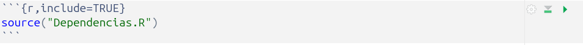

**Output:**

```r
source("Dependencias.R")
```

**Input:**

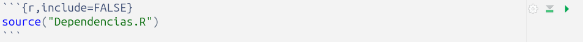

**Output:**

## Opción “echo”

La opción `echo` permite incluir siempre los outputs, pero elige si se muestra o no el código que lo genera. En este caso, con `echo=TRUE` se elige mostrar el código.

**Input:**

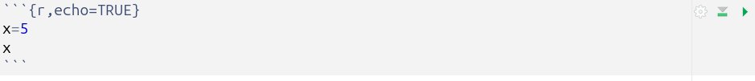

**Output:**

```r
x=5
x
```

```
## [1] 5
```

## Opción “echo”

La opción `echo` permite incluir siempre los outputs, pero elige si se muestra o no el código que lo genera. En este caso, con `echo=FALSE` se elige ocultar el código, pero notar que se muestra el output.

**Input:**

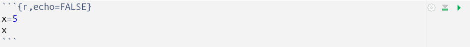

**Output:**

```
## [1] 5
```

## Opción “eval”

La opción `eval` permite mostrar código que puede llegar a ser problemático, pero cuyos errores se quieren enfatizar en la presentación. Si `eval=TRUE`, se elige mostrar el código y correrlo para que muestre cuál es el error.

**Input:**

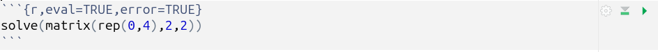

**Output:**

```
## Error in solve.default(matrix(rep(0, 4), 2, 2)): Lapack routine dgesv: system is exactly singular: U[1,1] = 0
```

## Opción “eval”

La opción `eval` permite mostrar código que puede llegar a ser problemático, pero cuyos errores se quieren enfatizar en la presentación. Si `eval=FALSE`, se elige mostrar el código, pero no correrlo.

**Input:**

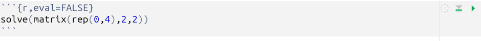

**Output:**

```r
solve(matrix(rep(0,4),2,2))
```

## Opción “message”

La opción `message` permite mostrar u ocultar mensajes automáticos del lenguaje de programación. En este caso, con `message=TRUE` se muestra el mensaje presente en el código.

**Input:**

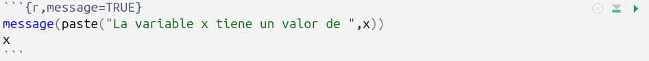

**Output:**

```
## La variable x tiene un valor de  5
```

```
## [1] 5
```

## Opción “message”

La opción `message` permite mostrar u ocultar mensajes automáticos del lenguaje de programación. En este caso, con `message=FALSE` se oculta el mensaje presente en el código.

**Input:**

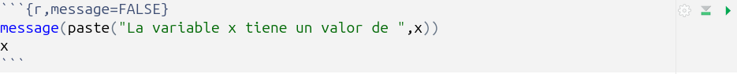

**Output:**

```
## [1] 5
```

## Opción “warning”

La opción `warning` permite mostrar u ocultar mensajes de advertencia automáticos del lenguaje de programación. En este caso, con `warning=TRUE` se muestra la advertencia presente en el código.

**Input:**

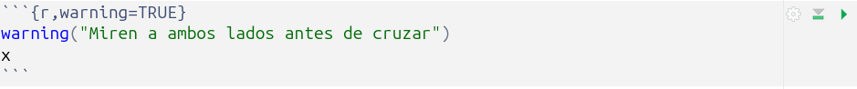

**Output:**

```
## Warning: Miren a ambos lados antes de cruzar
```

```
## [1] 5
```

## Opción “warning”

La opción `warning` permite mostrar u ocultar mensajes de advertencia automáticos del lenguaje de programación. En este caso, con `warning=FALSE` se oculta la advertencia presente en el código.

**Input:**

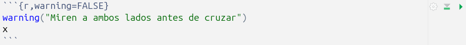

**Output:**

```
## [1] 5
```

## Tamaño de figura

Cuando agregamos gráficos de `R`, a veces es necesario ajustar el tamaño de la figura. Se hace del siguiente modo:

**Input:**

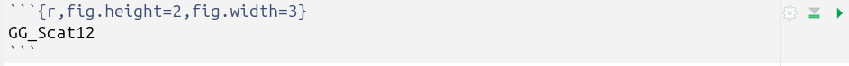

**Output:**

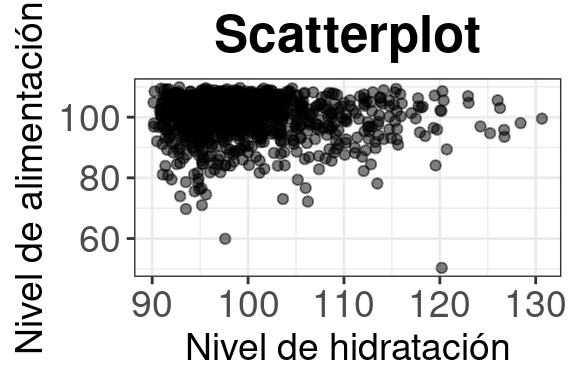

## Tamaño de figura

También los gráficos se pueden alinear a izquierda, derecha o centrar.

**Input:**

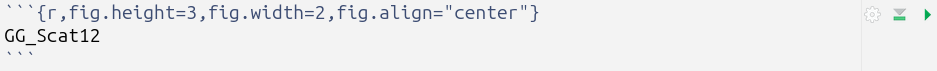

**Output:**

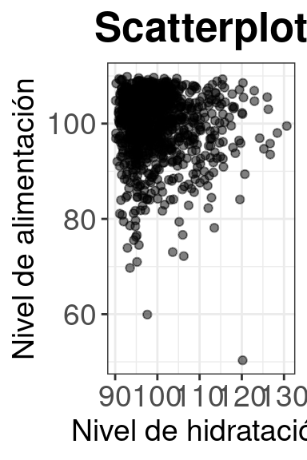

## Incluir gráficos externos (pdf)

Si se elige hacer una presentación o documento en pdf, se añade una imagen externa con los siguientes comandos. Se pueden ajustar tanto la altura, como el ancho de la imagen.

**Input:**

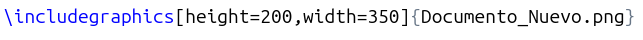

## Incluir gráficos externos (html)

Si se elige hacer una presentación o documento en html, se añade una imagen externa con los siguientes comandos. Se pueden ajustar tanto la altura, como el ancho de la imagen.

**Input:**

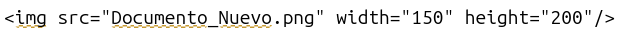

## Compilación

Luego de generar el texto y los códigos, se compila el documento en el que se ejecutan todos los códigos y se generan los outputs.

[figure not shown]

## Configuración default de opciones

En vez de estar configurando todos los fragmentos de código, a veces se pueden establecer opciones como default, y solo cambiar las opciones de los fragmentos que requieran alguna particularidad.

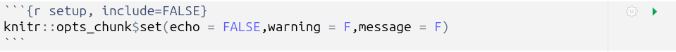